# BiPOCD_Modeling_1: Linear models for classification

Sebastian Sauer

21 Juli 2016

# 1 Modeling BiPOCD

We load the data that has been prepared in the previous step. Dimension of the dataset (r/c):

```r
data_class <- read_csv("../raw_data/data_mod3.csv")
data_class$responder_3m_f <- factor(data_class$responder_3m_f)
dim(data_class)
```

```
## [1] 56 44
```

Project directory should be “/analysis”; project directory is:

```r
getwd()
```

```
## [1] "/Users/sebastiansauer/Documents/OneDrive/Forschung/Online_Behavior_Therapy/analysis"
```

```r
save_model_results <- function(obj,
                               test_df = test_sample,
                               predict_results = TRUE,
                               report_varimp = TRUE,
                               fit_pred = "none",
                               conf_matrix = "none"){

  results <- list()

  results$fit <- obj
  results$name <- deparse(substitute(obj))


  if (predict_results == TRUE){
    message("Computing predictiong. Predicted values are: \n")
    fit_pred <- predict(obj, test_df)

    print(fit_pred)

    if (conf_matrix != "none"){
      message("confusion matrix for predicted values and factual values: \n")
      results$confusion_matrix <- confusionMatrix(data = fit_pred, test_df$responder_3m_f)
      print(results$confusion_matrix)
    }
  }

  if (report_varimp == TRUE){
    results$varimp <- varImp(obj, scale = FALSE)
    print(results$varimp)
  }

  if (fit_pred != "none") {
    message("prediction object saved to results list.")
    results$prediction_results <- fit_pred

  } else {
    message("prediction object not found.")
  }


   if (exists("conf_matrix") & (conf_matrix != "none")) {
    message("confusion matrix object saved to results list.")
    results$confusion_matrix <- conf_matrix

  } else {
    message("prediction object not found.")
  }


  return(results)
}
```

# 2 Basic classification (dichotomous outcome)

As we have two outcomes, one dichotomous and one metric, we can both do classification and regression. Let’s look at classification first.

Before I forget: we need to exclude the metric outcome variable `CYBOCS_3m`.

```r
exclude_metric_outcome <- function(data_df = data_class){
  if ("CYBOCS_3m" %in% names(data_df)) {
    data_df <- dplyr::select(data_df, -CYBOCS_3m)
    message("CYBOCS_3m has been excluded from the data set\n")
  }else {
   message("CYBOCS_3m was not in data frame")
  }
  return(data_df)
}

data_class <- exclude_metric_outcome(data_class)
```

Numer of columns in `data_class`: 43.

```r
test_split_data <- function(data_df = data_class){
  cat("Class of DV:\n")
  print(str(data_df$responder_3m_f))
  print(str(data_df$responder_3m_f))
  print(str(data_df$responder_3m_f))


  if ("CYBOCS_3m" %in% names(data_df)) warning("CYBOCS_3m is *in* test sample")
  if (!("CYBOCS_3m" %in% names(data_df))) message("CYBOCS_3m is NOT in test sample")
  message("done")
}

test_split_data(data_class)
```

```
## Class of DV:
##  Factor w/ 2 levels "0","1": 2 1 1 1 1 1 2 2 1 2 ...
## NULL
##  Factor w/ 2 levels "0","1": 2 1 1 1 1 1 2 2 1 2 ...
## NULL
##  Factor w/ 2 levels "0","1": 2 1 1 1 1 1 2 2 1 2 ...
## NULL
```

```r
set.seed(42)
trainIndex <- createDataPartition(data_class$responder_3m_f, p = .8,
                                  list = FALSE,
                                  times = 1)

train_sample <- data_class[trainIndex, ]
test_sample <- data_class[-trainIndex, ]




if (test_it ==  TRUE) test_split_data()
```

```
## Class of DV:
##  Factor w/ 2 levels "0","1": 2 1 1 1 1 1 2 2 1 2 ...
## NULL
##  Factor w/ 2 levels "0","1": 2 1 1 1 1 1 2 2 1 2 ...
## NULL
##  Factor w/ 2 levels "0","1": 2 1 1 1 1 1 2 2 1 2 ...
## NULL
```

## 2.1 LM

Let’s fit a linear logistic model. The model showed some problems with factor variables that have sparsely populated levels. Additionally, the ratio of variables to observations is not really nice. We probably will not arrive anywhere with this model.

```r
do_glmfit1 <- function(data_df = data_class){

  ctrl <- trainControl(method = "repeatedcv",
                       repeats = 5,
                       number = 10)

  glmfit1 <- train(factor(responder_3m_f) ~ .,
                   data = data_df,
                   method = "glm",
                   trControl = ctrl)

  return(glmfit1)

}

glmfit1 <- do_glmfit1(train_sample)
summary(glmfit1)
```

```
##
## Call:
## NULL
##
## Deviance Residuals:
##         X1          X2          X3          X4          X5          X6
##  2.110e-08  -2.538e-06  -1.559e-06  -1.870e-06   2.823e-06  -2.320e-06
##         X7          X8          X9         X10         X11         X12
##  3.336e-06   2.611e-06  -2.110e-08   3.532e-06  -2.902e-06   2.097e-06
##        X13         X14         X15         X16         X17         X18
## -2.131e-06   2.187e-06  -4.214e-06  -2.456e-06  -2.265e-06  -2.404e-06
##        X19         X20         X21         X22         X23         X24
## -2.450e-06   3.930e-06   1.945e-06   3.242e-06  -4.485e-06   3.165e-06
##        X25         X26         X27         X28         X29         X30
##  1.199e-06   1.409e-06   3.853e-06  -2.946e-06   3.494e-06  -2.387e-06
##        X31         X32         X33         X34         X35         X36
##  3.729e-06   3.367e-06  -3.214e-06   2.054e-06   1.954e-06   2.449e-06
##        X37         X38         X39         X40         X41         X42
##  3.027e-06   2.165e-06   2.740e-06   2.022e-06  -2.471e-06   2.110e-08
##        X43         X44         X45         X46
## -4.560e-06  -2.757e-06   3.314e-06   2.510e-06
##
## Coefficients: (1 not defined because of singularities)
##                               Estimate Std. Error z value Pr(>|z|)
## (Intercept)                 -4.045e+01  2.645e+06       0        1
## CYBOCS_pre_OBS              -8.688e+00  8.327e+04       0        1
## CYBOCS_pre_COMP              3.475e+00  2.361e+05       0        1
## CYBOCS_pre_insight          -1.604e+00  3.091e+05       0        1
## CYBOCS_pre_avoid             5.884e+00  2.884e+05       0        1
## ChOCI_R_C_sumsym_PRE        -1.367e+00  5.544e+04       0        1
## ChOCI_R_C_sumimp_PRE        -2.172e+00  6.774e+04       0        1
## EWSASC_sum_PRE               6.151e-01  2.543e+04       0        1
## SCAS_S_C_sum_PRE             2.950e+00  4.983e+04       0        1
## CDI_S_sum_PRE                3.059e+00  1.493e+05       0        1
## ChOCI_R_P_sumsym_PRE         2.428e+00  5.814e+04       0        1
## ChOCI_R_P_sumimp_PRE        -9.088e-01  3.169e+04       0        1
## FAS_PR_sum_PRE               4.000e-01  2.998e+04       0        1
## EWSASP_sum_PRE              -1.622e-01  2.899e+04       0        1
## SCAS_S_P_sum_PRE            -7.396e+00  5.859e+04       0        1
## Depression                   4.906e+01  1.333e+06       0        1
```

[output cut: 20 more lines]

```
## treatm_expnone               9.966e+01  1.229e+06       0        1
## OCD_treatm_expnone          -5.800e+01  5.217e+05       0        1
## CGI_S_pre                    5.262e+01  5.457e+05       0        1
## checking                     1.540e+00  4.342e+05       0        1
## obsessions                   3.666e+01  5.335e+05       0        1
## contamination               -4.155e+01  6.108e+05       0        1
## symmetry                    -5.307e+01  3.428e+05       0        1
##
## (Dispersion parameter for binomial family taken to be 1)
##
##     Null deviance: 6.2371e+01  on 45  degrees of freedom
## Residual deviance: 3.5054e-10  on  4  degrees of freedom
## AIC: 84
##
## Number of Fisher Scoring iterations: 25
```

```r
print(glmfit1)
```

```
## Generalized Linear Model
##
## 46 samples
## 42 predictors
##  2 classes: '0', '1'
##
## No pre-processing
## Resampling: Cross-Validated (10 fold, repeated 5 times)
## Summary of sample sizes: 41, 41, 41, 42, 42, 42, ...
## Resampling results:
##
##   Accuracy   Kappa
##   0.4876667  -0.0322977
##
##
```

```r
confusionMatrix(glmfit1)
```

```
## Cross-Validated (10 fold, repeated 5 times) Confusion Matrix
##
## (entries are percentual average cell counts across resamples)
##
##           Reference
## Prediction    0    1
##          0 21.7 31.3
##          1 19.6 27.4
##
##  Accuracy (average) : 0.4913
```

```r
mod_results$glmfit1 <- save_model_results(glmfit1)
```

```
## Computing predictiong. Predicted values are:
```

```
##  [1] 1 0 0 1 1 0 0 1 1 0
## Levels: 0 1
## glm variable importance
##
##   only 20 most important variables shown (out of 41)
##
##                               Overall
## symmetry                    1.548e-04
## SCAS_S_P_sum_PRE            1.262e-04
## OCD_treatm_expnone          1.112e-04
## CYBOCS_pre_OBS              1.043e-04
## CGI_S_pre                   9.642e-05
## medicationSSRI              8.199e-05
## treatm_expnone              8.111e-05
## treatm_expCAMHS.councelling 7.126e-05
## obsessions                  6.871e-05
## contamination               6.803e-05
## SCAS_S_C_sum_PRE            5.921e-05
## contactSelf.referral        5.818e-05
## GAD                         5.065e-05
## BirthcountryOther.european  4.924e-05
## age                         4.586e-05
## ChOCI_R_P_sumsym_PRE        4.175e-05
## medicationnone              3.853e-05
## Depression                  3.679e-05
## TourettesTics               3.322e-05
## ChOCI_R_C_sumimp_PRE        3.207e-05
```

```
## prediction object saved to results list.
```

```
## prediction object not found.
```

```r
#
# dummy <- predict(glmfit1, test_sample)
#
# confusionMatrix(dummy, test_sample$responder_3m_f)
# str(test_sample$responder_3m_f)
```

Classification rate was …bad…? But now look at the variable importance. Note:

> Linear Models: the absolute value of the t–statistic for each model parameter is used.

(From caret help `varimp`.)

```r
mod_results$glmfit1$varimp[[1]] %>%
  as_tibble %>%
  #dplyr::select(everything()) %>%
  rownames_to_column %>%
  arrange(desc(Overall))%>%
  top_n(5) %>%
  kable
```

| rowname | Overall |
| --- | --- |
| symmetry | 0.0001548 |
| SCAS_S_P_sum_PRE | 0.0001262 |
| OCD_treatm_expnone | 0.0001112 |
| CYBOCS_pre_OBS | 0.0001043 |
| CGI_S_pre | 0.0000964 |

Only top-5 shown.

Let’s look at McFadden’s pseudo R^2. Note that we here too have to fit the model using the train sample, but judge perfomance on the test sample.

```r
glmfit1 <- glm(responder_3m_f ~ .,
               data = train_sample,
               family = "binomial",
               control = list(maxit = 50))
pR2(glmfit1)
```

```
##           llh       llhNull            G2      McFadden          r2ML
## -1.235350e-10 -3.118557e+01  6.237114e+01  1.000000e+00  7.815607e-01
##          r2CU
##  1.000000e+00
```

Here, the algorithm tells us that we ran into problems; it may well be that we have too many predictors. MacFadden’s R^2 is 1; appears too good to be true.

Although not undebated among statisticians, let’s try a stepwise regression instead (Gelman detests it, but Hastie/Tibshirani seem to be ok with it)

## 2.2 Stepwise LM

```r
do_glmfit2 <- function(save_results = FALSE, data_df = train_sample, n_repeats = 10,
                       n_folds = 10){

  ctrl <- caret::trainControl(method = "repeatedcv",
                       repeats = n_repeats,
                       number = n_folds)  # folds

  if ("ID" %in% names(data_df)) data_df <- dplyr::select(data_df, -ID)

  glmfit2 <- caret::train(responder_3m_f ~ .,
                   data = data_df,
                   method = "glmStepAIC",
                   trControl = ctrl,
                   verbose = TRUE)   # takes some minutes! *expensive*


  if (save_results == TRUE) {
    save(glmfit2, file = "data_objects/glmfit2.Rda")
    cat("writing object to file (in working directory)\n")
  }

  return(glmfit2)
}
```

```r
glmfit2_pred <- predict(glmfit2, newdata = test_sample)
# length(glmfit2_pred)



mod_results$glmfit2$fit <- glmfit2
(mod_results$glmfit2$confusion_matrix <- confusionMatrix(data = glmfit2_pred, test_sample$responder_3m_f))
```

```
## Confusion Matrix and Statistics
##
##           Reference
## Prediction 0 1
##          0 1 4
##          1 3 2
##
##                Accuracy : 0.3
##                  95% CI : (0.0667, 0.6525)
##     No Information Rate : 0.6
##     P-Value [Acc > NIR] : 0.9877
##
##                   Kappa : -0.4
##  Mcnemar's Test P-Value : 1.0000
##
##             Sensitivity : 0.2500
##             Specificity : 0.3333
##          Pos Pred Value : 0.2000
##          Neg Pred Value : 0.4000
##              Prevalence : 0.4000
##          Detection Rate : 0.1000
##    Detection Prevalence : 0.5000
##       Balanced Accuracy : 0.2917
##
##        'Positive' Class : 0
##
```

```r
mod_results$glmfit2$name <- "glmfit2"
#mod_results$glmfit2$varimp <- varImp(glmfit2, scale = FALSE)



# cat("Class of DV:\n")
# str(data_class$responder_3m_f)
# str(train_sample$responder_3m_f)
# str(test_sample$responder_3m_f)
```

Hm, that’s not so enlightning. Let’s try a different function, `leaps::regsubsets`. Let’s do forward selection. Max. nr. of predictors to be included: 10. Note: Here we take the full dataset for model selection. But at least, we use statistics which take the number of predictors into account when choosing the “right” model.

```r
library(leaps)
glmfit3 <- regsubsets(responder_3m_f ~ . , data = data_class,
                      nvmax = 10,
                      method = "forward")
```

```
## Reordering variables and trying again:
```

```r
glmfit3_summary <- summary(glmfit3)
glmfit3_summary
```

```
## Subset selection object
## Call: regsubsets.formula(responder_3m_f ~ ., data = data_class, nvmax = 10,
##     method = "forward")
## 42 Variables  (and intercept)
##                             Forced in Forced out
## CYBOCS_pre_OBS                  FALSE      FALSE
## CYBOCS_pre_COMP                 FALSE      FALSE
## CYBOCS_pre_insight              FALSE      FALSE
## CYBOCS_pre_avoid                FALSE      FALSE
## ChOCI_R_C_sumsym_PRE            FALSE      FALSE
## ChOCI_R_C_sumimp_PRE            FALSE      FALSE
## EWSASC_sum_PRE                  FALSE      FALSE
## SCAS_S_C_sum_PRE                FALSE      FALSE
## CDI_S_sum_PRE                   FALSE      FALSE
## ChOCI_R_P_sumsym_PRE            FALSE      FALSE
## ChOCI_R_P_sumimp_PRE            FALSE      FALSE
## FAS_PR_sum_PRE                  FALSE      FALSE
## EWSASP_sum_PRE                  FALSE      FALSE
## SCAS_S_P_sum_PRE                FALSE      FALSE
## Depression                      FALSE      FALSE
## PanicDisorder                   FALSE      FALSE
## SocialPhob                      FALSE      FALSE
## SpecificPhob                    FALSE      FALSE
## TourettesTics                   FALSE      FALSE
## ADHD                            FALSE      FALSE
## GAD                             FALSE      FALSE
## numberdiagnos                   FALSE      FALSE
## sexgirl                         FALSE      FALSE
## age                             FALSE      FALSE
## BirthcountryOther.european      FALSE      FALSE
## BirthcountrySweden              FALSE      FALSE
## Education_parentHigh.school     FALSE      FALSE
## Education_parentOther           FALSE      FALSE
## Education_parentUniversity      FALSE      FALSE
## contactSelf.referral            FALSE      FALSE
## distance                        FALSE      FALSE
## medicationnone                  FALSE      FALSE
## medicationSSRI                  FALSE      FALSE
## treatm_expCAMHS.councelling     FALSE      FALSE
## treatm_expnone                  FALSE      FALSE
```

[output cut: 138 more lines]

```
## 9  ( 1 )  "*"                         " "            " "
## 10  ( 1 ) "*"                         " "            " "
## 11  ( 1 ) "*"                         " "            " "
##           CGI_S_pre checking obsessions contamination symmetry
## 1  ( 1 )  " "       " "      " "        "*"           " "
## 2  ( 1 )  " "       " "      " "        "*"           " "
## 3  ( 1 )  " "       " "      " "        "*"           " "
## 4  ( 1 )  " "       " "      " "        "*"           " "
## 5  ( 1 )  "*"       " "      " "        "*"           " "
## 6  ( 1 )  "*"       " "      " "        "*"           " "
## 7  ( 1 )  "*"       " "      " "        "*"           " "
## 8  ( 1 )  "*"       " "      " "        "*"           " "
## 9  ( 1 )  "*"       " "      " "        "*"           " "
## 10  ( 1 ) "*"       " "      "*"        "*"           " "
## 11  ( 1 ) "*"       " "      "*"        "*"           " "
```

```r
# names(glmfit3_summary)
#str(glmfit3)
#which.max(glmfit3$adjr2)


mod_results$glmfit3 <- save_model_results(glmfit3,
                                          predict_results = FALSE,
                                          report_varimp = FALSE)
```

So let’s look which variables have been included to the models (starting with 1 predictor to a model with 10 predictors):

```r
for (i in 1:10) {
  cat(paste("***Model with ",i," predictor(s)***\n", paste = ""))
  print(coef(glmfit3, i))
}
```

```
## ***Model with  1  predictor(s)***
##  (Intercept)    symmetry
##   1.7647059  -0.2518854
## ***Model with  2  predictor(s)***
##    (Intercept) CDI_S_sum_PRE      symmetry
##    1.62863184    0.02542043   -0.21097497
## ***Model with  3  predictor(s)***
##    (Intercept) CDI_S_sum_PRE  SpecificPhob      symmetry
##    1.58639252    0.03793374   -0.42064339   -0.15086601
## ***Model with  4  predictor(s)***
##     (Intercept)  CDI_S_sum_PRE   SpecificPhob treatm_expnone       symmetry
##      1.5053851      0.0434449     -0.4162535      0.1089025     -0.1581824
## ***Model with  5  predictor(s)***
##     (Intercept)  CDI_S_sum_PRE   SpecificPhob treatm_expnone       checking
##     1.52612854     0.04546336    -0.42371985     0.12187191    -0.09037237
##       symmetry
##    -0.16550775
## ***Model with  6  predictor(s)***
##     (Intercept)  CDI_S_sum_PRE   SpecificPhob medicationSSRI treatm_expnone
##     1.54499468     0.04668657    -0.41567232    -0.11193473     0.11144312
##       checking       symmetry
##    -0.09335077    -0.16276614
## ***Model with  7  predictor(s)***
##                  (Intercept)               CDI_S_sum_PRE
##                  1.59168004                  0.04879484
##                SpecificPhob Education_parentHigh.school
##                 -0.43015062                 -0.30403105
##              medicationSSRI              treatm_expnone
##                 -0.10620588                  0.16753331
##                    checking                    symmetry
##                 -0.08146203                 -0.19975029
## ***Model with  8  predictor(s)***
##                  (Intercept)               CDI_S_sum_PRE
##                  1.69165762                  0.05376589
##                SpecificPhob                         GAD
##                 -0.49943841                 -0.47639126
## Education_parentHigh.school              medicationSSRI
##                 -0.37689268                 -0.12058045
##              treatm_expnone                    checking
##                  0.09831710                  0.03054227
```

[output cut: 11 more lines]

```
##                    checking                    symmetry
##                  0.04773001                 -0.26333989
## ***Model with  10  predictor(s)***
##                  (Intercept)              CYBOCS_pre_OBS
##                 1.314514156                -0.006333782
##               CDI_S_sum_PRE                SpecificPhob
##                 0.068969769                -0.506477482
##                         GAD Education_parentHigh.school
##                -0.361614509                -0.329892809
##              medicationSSRI              treatm_expnone
##                -0.146920208                 0.137839495
##                    checking               contamination
##                 0.028093421                 0.353681188
##                    symmetry
##                -0.084475839
```

Ok, but which model (ie, with what number of predictors) should we choose?

Let’s look at *adjusted* $R^2$.

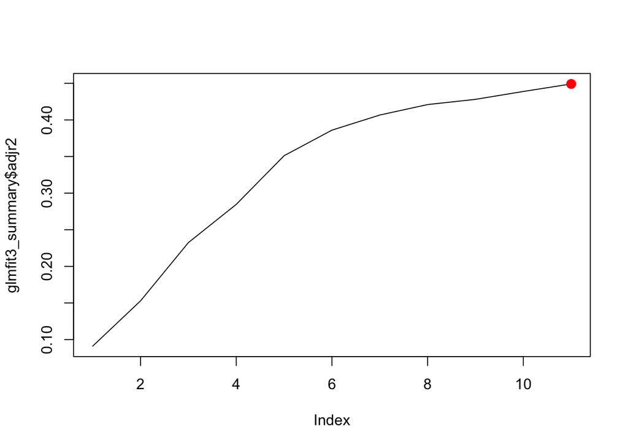

```r
plot(glmfit3_summary$adjr2, type = "l")
nr_predictors <- which.max(glmfit3_summary$adjr2)
points(nr_predictors, glmfit3_summary$adjr2[nr_predictors], col = "red", cex = 2, pch = 20)
```

That is, the model suggests 11 predictors to be included.

Let’s look at $BIC$.

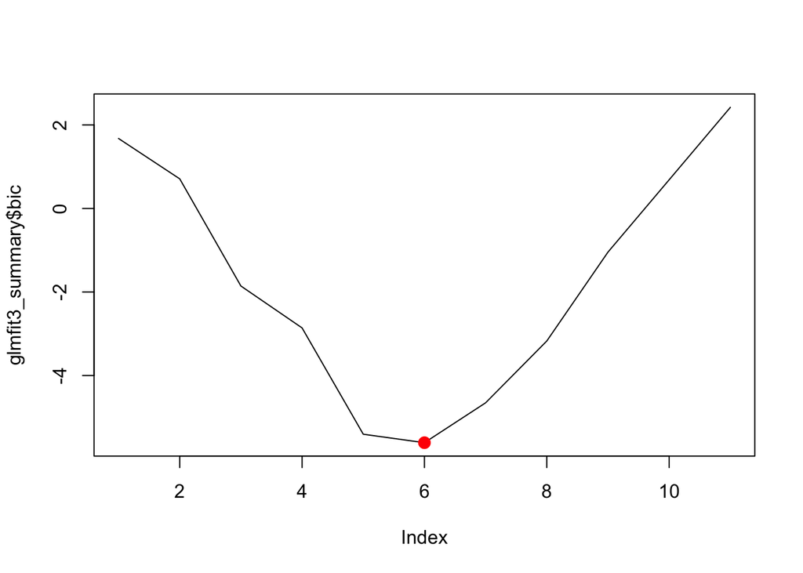

```r
plot(glmfit3_summary$bic, type = "l")
nr_predictors <- which.min(glmfit3_summary$bic)
points(nr_predictors, glmfit3_summary$bic[nr_predictors], col = "red", cex = 2, pch = 20)
```

That is, the model suggests 6 predictors to be included.

$BIC$ is more strict in terms of allowing predictors to enter the model. So let’s look finally to $C_p$:

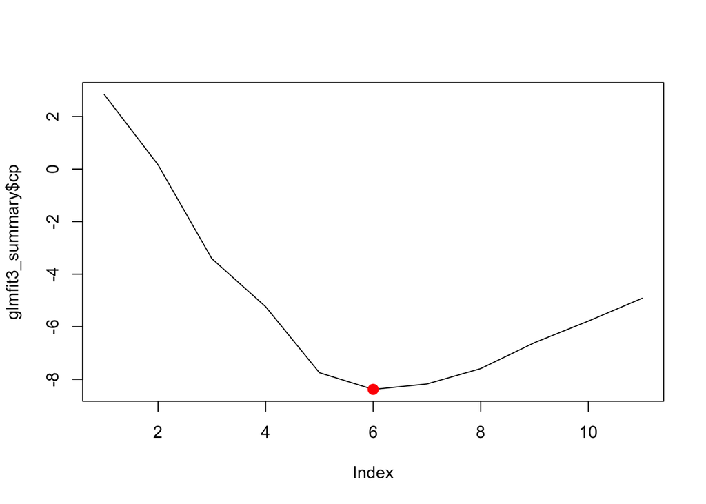

```r
plot(glmfit3_summary$cp, type = "l")
nr_predictors <- which.min(glmfit3_summary$cp)
points(nr_predictors, glmfit3_summary$cp[nr_predictors], col = "red", cex = 2, pch = 20)
```

That is, the model suggests 6 predictors to be included.

Ok, so let’s stick to 6 predictors. These are:

```r
coef(glmfit3, nr_predictors)[-1]
```

```
##  CDI_S_sum_PRE   SpecificPhob medicationSSRI treatm_expnone       checking
##     0.04668657    -0.41567232    -0.11193473     0.11144312    -0.09335077
##       symmetry
##    -0.16276614
```

```r
best_preds <- names(coef(glmfit3, nr_predictors))[-1]  # first is "intercept"
```

# 3 LM with reduced number of predictors

Ok, now again a linear (logistic) model with the reduced number of predictors. Remember that we work with a train and test sample all the time.

```r
ctrl <- trainControl(method = "repeatedcv",
                     repeats = 10,
                     number = 100)


train_best_preds <- dplyr::select(train_sample, one_of(best_preds), responder_3m_f)
test_best_preds <- dplyr::select(test_sample, one_of(best_preds), responder_3m_f)

expect_that(names(train_best_preds), is_identical_to(names(test_best_preds)))


glmfit4 <- train(factor(responder_3m_f) ~ .,
                 data = train_best_preds,
                 method = "glm",
                 trControl = ctrl)
summary(glmfit4)
```

```
##
## Call:
## NULL
##
## Deviance Residuals:
##     Min       1Q   Median       3Q      Max
## -1.6839  -1.0623   0.5311   0.8658   1.8658
##
## Coefficients:
##                Estimate Std. Error z value Pr(>|z|)
## (Intercept)      0.2244     1.0971   0.205   0.8379
## CDI_S_sum_PRE    0.2679     0.1384   1.936   0.0529 .
## SpecificPhob    -2.1219     1.2802  -1.658   0.0974 .
## medicationSSRI  -1.2707     1.0663  -1.192   0.2334
## treatm_expnone   1.1120     0.7994   1.391   0.1642
## checking        -1.1494     0.7571  -1.518   0.1289
## symmetry        -0.9998     0.8842  -1.131   0.2582
## ---
## Signif. codes:  0 '***' 0.001 '**' 0.01 '*' 0.05 '.' 0.1 ' ' 1
##
## (Dispersion parameter for binomial family taken to be 1)
##
##     Null deviance: 62.371  on 45  degrees of freedom
## Residual deviance: 50.787  on 39  degrees of freedom
## AIC: 64.787
##
## Number of Fisher Scoring iterations: 4
```

```r
dimnames(summary(glmfit4)$coefficients)[[1]] -> glmfit4_preds

summary(glmfit4)$coefficients %>% as_tibble %>%
  mutate(predictors = glmfit4_preds) %>%
  dplyr::select(predictors, Estimate:`Pr(>|z|)`) ->
  glmfit4_coefs

kable(glmfit4_coefs)
```

| predictors | Estimate | Std. Error | z value | Pr(>\|z\|) |
| --- | --- | --- | --- | --- |
| (Intercept) | 0.2243982 | 1.0970991 | 0.2045377 | 0.8379333 |
| CDI_S_sum_PRE | 0.2679317 | 0.1384149 | 1.9357141 | 0.0529027 |
| SpecificPhob | -2.1219421 | 1.2801827 | -1.6575306 | 0.0974122 |
| medicationSSRI | -1.2707433 | 1.0663004 | -1.1917311 | 0.2333667 |
| treatm_expnone | 1.1120461 | 0.7993564 | 1.3911768 | 0.1641718 |
| checking | -1.1494065 | 0.7570539 | -1.5182625 | 0.1289482 |
| symmetry | -0.9998477 | 0.8842359 | -1.1307477 | 0.2581613 |

```r
mod_results$glmfit4 <- save_model_results(glmfit4, test_df = test_best_preds)
```

```
##  [1] 1 0 0 1 1 1 1 1 1 1
## Levels: 0 1
## glm variable importance
##
##                Overall
## CDI_S_sum_PRE    1.936
## SpecificPhob     1.658
## checking         1.518
## treatm_expnone   1.391
## medicationSSRI   1.192
## symmetry         1.131
```

```r
mod_results$glmfit4$fit$results$Accuracy
```

```
## [1] 0.5869565
```

However, the accuracy in **test** sample is

```r
mod_results$glmfit4$confusion_matrix
```

[output not shown]

```r
glmfit4_coefs %>% rename(p_value = `Pr(>|z|)`) -> glmfit4_coefs
# easier name for typing

glmfit4_coefs %>%
  filter(p_value < .05) %T>% kable -> signif_preds


names(signif_preds$predictors)
```

```r
# signif_preds$predictors %in% names(data_class)
```

Ok, interesting.

Maybe let’s have a look at the distribution in the sample:

```r
if (length(signif_preds$predictors) > 0) {
  data_class %>%
    select(one_of(signif_preds$predictors), responder_3m_f) %>%
    gather(key = variable, value = value, -responder_3m_f) %>%
    ggplot(aes(x = responder_3m_f, y = value)) +
    facet_wrap(~variable, scales = "free") + geom_boxplot() + geom_jitter()
} else {
  message("There are no statistical significant predictors in current model")
}
```

Time to look at different models!

Don’t forget to save results to disk…

```r
save(mod_results, file = "mod_results.Rda")
```

We did not alter the data, so no need to same them to disk.